# Combining Ability Analysis of a Maize Factorial Cross

General Combining Ability (GCA) and Specific Combining Ability (SCA) from a 7 × 7 Factorial Design

Author

Fausto Rodríguez Zapata, assisted by Antigravity and Claude Code

Published

May 30, 2026

> [!NOTE] This Quarto notebook is designed to guide Stelio Boaventura Nuvunga through the statistical calculations for General Combining Ability (GCA) and Specific Combining Ability (SCA). It uses the simulated maize dataset representing his actual PhD research setup: a **7 × 7 Factorial Mating (Line × Tester) F1 hybrid cross evaluated across 2 environments in an RCBD with 3 replications**.

# 1 Theoretical Foundation & Experimental Setup

Before performing calculations in R, we must define the genetic breeding scheme, the field experimental design, and the mathematical phenotype model.

## 1.1 Breeding Scheme (Line × Tester)

Stelio’s research focuses on the genetic architecture of low-phosphorus use efficiency (PUE) in maize. The mating design is a **Factorial Mating Design** (often referred to as a **Line × Tester / North Carolina Design II**). * **Female Parents (Lines - PUE Donors from CIMMYT):** 7 low-P tolerant inbred lines:
$$\text{CML364, CML366, CML434, CML435, CML439, CML440, and CML532}$$
* **Male Parents (Testers - Local elite lines from Mozambique):** 7 well-adapted but susceptible lines (labeled `MOZ1` to `MOZ7`). * **Hybrid Families ($F_1$):** All possible crosses between the 7 females and 7 males are made, yielding a total of **49 unique $F_1$ hybrid combinations**. * **Genetic Advantage:** Unlike a diallel, a factorial mating design utilizes two distinct, mutually exclusive parental sets. This prevents selfing or reciprocal cross complications.

### 1.1.1 Stelio’s Factorial Mating Grid

Each cell represents an $F_1$ hybrid family evaluated in the field.

| CIMMYT Donors (Females) | MOZ1 | MOZ2 | MOZ3 | MOZ4 | MOZ5 | MOZ6 | MOZ7 |
| --- | --- | --- | --- | --- | --- | --- | --- |
| **CML364** | $F_1$ | $F_1$ | $F_1$ | $F_1$ | $F_1$ | $F_1$ | $F_1$ |
| **CML366** | $F_1$ | $F_1$ | $F_1$ | $F_1$ | $F_1$ | $F_1$ | $F_1$ |
| **CML434** | $F_1$ | $F_1$ | $F_1$ | $F_1$ | $F_1$ | $F_1$ | $F_1$ |
| **CML435** | $F_1$ | $F_1$ | $F_1$ | $F_1$ | $F_1$ | $F_1$ | $F_1$ |
| **CML439** | $F_1$ | $F_1$ | $F_1$ | $F_1$ | $F_1$ | $F_1$ | $F_1$ |
| **CML440** | $F_1$ | $F_1$ | $F_1$ | $F_1$ | $F_1$ | $F_1$ | $F_1$ |
| **CML532** | $F_1$ | $F_1$ | $F_1$ | $F_1$ | $F_1$ | $F_1$ | $F_1$ |

## 1.2 Experimental Design

The 49 $F_1$ hybrids are evaluated under a **Randomized Complete Block Design (RCBD)** with **3 replications (blocks)** per environment. * **Environments ($E$):** The trials are conducted across **2 environments** representing phosphorus treatment levels: 1. **env1:** Normal/High Phosphorus conditions. 2. **env2:** Low Phosphorus Stress conditions. * **Trait Evaluated:** Grain Yield (tons/ha). * **Total Plots:** $2 \text{ environments} \times 3 \text{ replications} \times 49 \text{ hybrid entries} = 294$ plot evaluations.

## 1.3 Phenotype Model (Mathematical Equation)

To analyze the phenotypic yield data, we model the value of a plot containing hybrid $pq$ (cross of female parent $p$ and male parent $q$) in block $j$ of environment $i$ as:

$$y_{ijpq} = \mu + E_i + B_{j(i)} + g_{F_p} + g_{M_q} + s_{pq} + (Eg_{F})_{ip} + (Eg_{M})_{iq} + (Es)_{ipq} + \epsilon_{ijpq}$$

Where: * $y_{ijpq}$ is the grain yield observed in the plot.

- $\mu$ is the overall mean grain yield of the population.
- $E_i$ is the fixed effect of the $i$-th environment (phosphorus treatment).
- $B_{j(i)}$ is the random effect of the $j$-th block nested within the $i$-th environment, assumed $B_{j(i)} \sim \text{NID}(0, \sigma^2_{B(E)})$.
- $g_{F_p}$ is the random General Combining Ability (GCA) effect of the $p$-th female parent, assumed $g_{F_p} \sim \text{NID}(0, \sigma^2_{GCA\_F})$. This represents the additive breeding value transmitted by the CIMMYT donor.
- $g_{M_q}$ is the random GCA effect of the $q$-th male parent, assumed $g_{M_q} \sim \text{NID}(0, \sigma^2_{GCA\_M})$. This represents the additive breeding value transmitted by the local tester.
- $s_{pq}$ is the random Specific Combining Ability (SCA) effect of the cross between female $p$ and male $q$, assumed $s_{pq} \sim \text{NID}(0, \sigma^2_{SCA})$. This represents dominance deviations (heterosis/hybrid vigor).
- $(Eg_{F})_{ip}$ and $(Eg_{M})_{iq}$ are the random interactions of the parental GCA effects with the environment, modeling how additive breeding values respond to low-phosphorus stress.
- $(Es)_{ipq}$ is the random interaction of the SCA effect with the environment, representing specific hybrid adaptability to stress.
- $\epsilon_{ijpq}$ is the residual experimental plot error, assumed $\epsilon_{ijpq} \sim \text{NID}(0, \sigma^2_{\epsilon})$.

> [!IMPORTANT] Because Stelio’s design uses distinct female and male lines (a factorial mating scheme), the parental effects are mutually exclusive. Unlike a diallel, **we do not need to overlay design matrices or use overlay functions** in mixed models. This significantly simplifies our mixed model code in R!

# 2 R Environment & Data Import

We load the necessary libraries and read the simulated maize dataset, which is stored in `/data/maize_factorial_yield.csv`.

```r
library(tidyverse)
library(sommer)
library(knitr)
library(kableExtra)

# Load the dataset
maize_data <- read_csv("data/maize_factorial_yield.csv")

# Convert design factors to R factors
maize_data <- maize_data %>%
  mutate(
    env = as.factor(env),
    block = as.factor(block),
    female = as.factor(female),
    male = as.factor(male),
    cross = as.factor(cross)
  )
```

# 3 Exploratory Data Analysis (EDA)

We visualize the grain yields of the 49 crosses across the two environments to understand the stress impact.

## 3.1 Mean Yield Grid

Let’s construct a grid of mean yields across all 3 replications, combined for both environments.

```r
mean_yields <- maize_data %>%
  group_by(female, male) %>%
  summarize(mean_yield = round(mean(yield), 2), .groups = 'drop') %>%
  pivot_wider(names_from = male, values_from = mean_yield)

kable(mean_yields, caption = "7 × 7 Factorial F1 Yield Grid (Combined Environments, tons/ha)") %>%
  kable_styling(bootstrap_options = c("striped", "hover", "bordered")) %>%
  row_spec(0, bold = TRUE, background = "#cc0000", color = "white")
```

7 × 7 Factorial F1 Yield Grid (Combined Environments, tons/ha)

| female | MOZ1 | MOZ2 | MOZ3 | MOZ4 | MOZ5 | MOZ6 | MOZ7 |
| --- | --- | --- | --- | --- | --- | --- | --- |
| CML364 | 10.48 | 9.78 | 9.25 | 9.64 | 8.95 | 8.49 | 8.11 |
| CML366 | 9.63 | 9.35 | 9.18 | 8.45 | 8.50 | 7.59 | 7.87 |
| CML434 | 9.46 | 9.33 | 8.62 | 8.46 | 7.96 | 7.82 | 7.08 |
| CML435 | 9.47 | 8.70 | 7.99 | 7.81 | 7.38 | 7.15 | 6.97 |
| CML439 | 8.92 | 8.17 | 7.97 | 7.66 | 7.28 | 7.11 | 6.68 |
| CML440 | 8.44 | 7.86 | 7.70 | 6.88 | 6.85 | 6.87 | 6.12 |
| CML532 | 8.27 | 7.44 | 7.30 | 6.43 | 6.38 | 6.05 | 5.78 |

## 3.2 Performance across Environments

Let’s visualize the yield distribution under Normal Phosphorus (`env1`) versus Low Phosphorus Stress (`env2`).

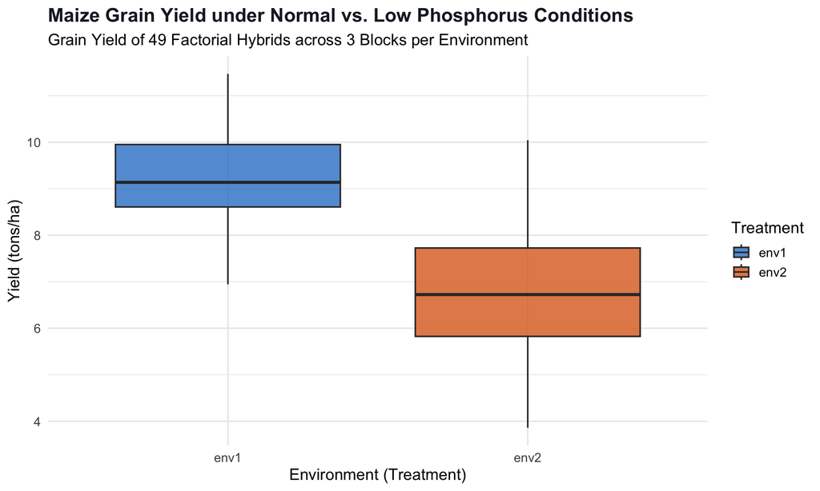

```r
ggplot(maize_data, aes(x = env, y = yield, fill = env)) +
  geom_boxplot(alpha = 0.8, outlier.color = "red") +
  scale_fill_manual(values = c("env1" = "#3182ce", "env2" = "#dd6b20")) +
  labs(
    title = "Maize Grain Yield under Normal vs. Low Phosphorus Conditions",
    subtitle = "Grain Yield of 49 Factorial Hybrids across 3 Blocks per Environment",
    x = "Environment (Treatment)",
    y = "Yield (tons/ha)",
    fill = "Treatment"
  ) +
  theme_minimal(base_size = 14) +
  theme(plot.title = element_text(face = "bold", color = "#1a202c"))
```

# 4 Fixed-Effects Calculations: Factorial Combining Ability

In a balanced factorial cross, GCA and SCA can be calculated arithmetically from family means. This provides a transparent foundation before using mixed models.

## 4.1 Arithmetic Formulas

Let $\bar{Y}_{p.}$ be the mean yield of all crosses involving female parent $p$. Let $\bar{Y}_{.q}$ be the mean yield of all crosses involving male parent $q$. Let $\bar{Y}_{pq}$ be the mean yield of the hybrid cross between female $p$ and male $q$. Let $\bar{Y}_{..}$ be the overall grand mean of all crosses in the factorial grid.

- **Grand Mean:**
  $$\bar{Y}_{..} = \frac{1}{f \cdot m} \sum_{p} \sum_{q} \bar{Y}_{pq}$$
- **GCA of Female Parent $p$ ($g_{F_p}$):**
  $$g_{F_p} = \bar{Y}_{p.} - \bar{Y}_{..}$$
- **GCA of Male Parent $q$ ($g_{M_q}$):**
  $$g_{M_q} = \bar{Y}_{.q} - \bar{Y}_{..}$$
- **SCA of Cross $pq$ ($s_{pq}$):**
  $$s_{pq} = \bar{Y}_{pq} - g_{F_p} - g_{M_q} - \bar{Y}_{..} = \bar{Y}_{pq} - \bar{Y}_{p.} - \bar{Y}_{.q} + \bar{Y}_{..}$$

## 4.2 Direct R Arithmetic

We calculate these effects arithmetically from the entire dataset.

```r
# 1. Calculate family means
family_means <- maize_data %>%
  group_by(female, male) %>%
  summarize(mean_yield = mean(yield), .groups = 'drop')

# 2. Reshape to a 7x7 matrix (7 females in rows, 7 males in columns)
Y_matrix <- matrix(0, nrow = 7, ncol = 7, dimnames = list(levels(maize_data$female), levels(maize_data$male)))
for(i in 1:nrow(family_means)) {
  Y_matrix[as.character(family_means$female[i]), as.character(family_means$male[i])] <- family_means$mean_yield[i]
}

# 3. Grand mean
mu_hat <- mean(Y_matrix)

# 4. Female and Male means
female_means <- rowMeans(Y_matrix)
male_means <- colMeans(Y_matrix)

# 5. GCA effects
gca_female_fixed <- female_means - mu_hat
gca_male_fixed <- male_means - mu_hat

# 6. SCA effects
sca_fixed <- matrix(0, nrow = 7, ncol = 7, dimnames = list(levels(maize_data$female), levels(maize_data$male)))
for(p in rownames(sca_fixed)) {
  for(q in colnames(sca_fixed)) {
    sca_fixed[p, q] <- Y_matrix[p, q] - gca_female_fixed[p] - gca_male_fixed[q] - mu_hat
  }
}

# Print Female GCA Effects
gca_female_df <- tibble(
  Female_Parent = names(gca_female_fixed),
  Mean_Yield = round(female_means, 3),
  Estimated_GCA = round(gca_female_fixed, 4)
)

kable(gca_female_df, caption = "Estimated GCA Effects for Female Parents (CIMMYT Lines)") %>%
  kable_styling(bootstrap_options = c("striped", "hover", "condensed"))
```

Estimated GCA Effects for Female Parents (CIMMYT Lines)

| Female_Parent | Mean_Yield | Estimated_GCA |
| --- | --- | --- |
| CML364 | 9.244 | 1.2516 |
| CML366 | 8.655 | 0.6622 |
| CML434 | 8.389 | 0.3963 |
| CML435 | 7.923 | -0.0697 |
| CML439 | 7.685 | -0.3070 |
| CML440 | 7.246 | -0.7468 |
| CML532 | 6.806 | -1.1866 |

```r
# Print Male GCA Effects
gca_male_df <- tibble(
  Male_Parent = names(gca_male_fixed),
  Mean_Yield = round(male_means, 3),
  Estimated_GCA = round(gca_male_fixed, 4)
)

kable(gca_male_df, caption = "Estimated GCA Effects for Male Parents (MOZ Testers)") %>%
  kable_styling(bootstrap_options = c("striped", "hover", "condensed"))
```

Estimated GCA Effects for Male Parents (MOZ Testers)

| Male_Parent | Mean_Yield | Estimated_GCA |
| --- | --- | --- |
| MOZ1 | 9.239 | 1.2461 |
| MOZ2 | 8.661 | 0.6687 |
| MOZ3 | 8.287 | 0.2943 |
| MOZ4 | 7.906 | -0.0868 |
| MOZ5 | 7.614 | -0.3783 |
| MOZ6 | 7.296 | -0.6964 |
| MOZ7 | 6.945 | -1.0477 |

# 5 Mixed-Effects Calculations: Factorial Variance Component Analysis

In modern breeding, combining ability is analyzed using **Linear Mixed Models (LMMs)**. Parents are treated as random samples from a reference population.

We use the R package `sommer` to fit the mixed model. Because female and male lines are distinct, **no matrix overlays are needed**. We analyze the **Low Phosphorus Stress environment (`env2`)** where selecting tolerant lines is critical.

## 5.1 Fitting the Mixed Model

The random terms in our model are: `female` (Female GCA), `male` (Male GCA), `cross` (SCA), and `block` (RCBD replication).

```r
# Filter for env2 (Low Phosphorus Stress)
data_env2 <- maize_data %>%
  filter(env == "env2") %>%
  mutate(
    female = as.factor(female),
    male = as.factor(male),
    cross = as.factor(cross),
    block = as.factor(block)
  )

# Fit Mixed Model in sommer
# yield = fixed intercept + random female GCA + random male GCA + random SCA + random block
fit_factorial <- mmer(
  fixed = yield ~ 1,
  random = ~ female + male + cross + block,
  data = data_env2,
  verbose = FALSE
)

# Extract and display variance components
var_comps <- summary(fit_factorial)$varcomp
kable(var_comps, caption = "Estimated Genetic and Environmental Variance Components in Low Phosphorus (env2)") %>%
  kable_styling(bootstrap_options = c("striped", "hover"))
```

Estimated Genetic and Environmental Variance Components in Low Phosphorus (env2)

|  | VarComp | VarCompSE | Zratio | Constraint |
| --- | --- | --- | --- | --- |
| female.yield-yield | 1.2281584 | 0.7152687 | 1.7170588 | Positive |
| male.yield-yield | 0.8074877 | 0.4724488 | 1.7091541 | Positive |
| cross.yield-yield | 0.0111465 | 0.0204295 | 0.5456056 | Positive |
| block.yield-yield | 0.0071273 | 0.0111675 | 0.6382118 | Positive |
| units.yield-yield | 0.1969197 | 0.0284226 | 6.9282774 | Positive |

## 5.2 Extracting GCA BLUPs (sommer)

We extract the General Combining Ability predictions (BLUPs) for both the female and male parent sets.

```r
# Extract random effects from fit
female_blups <- fit_factorial$U$female$yield
male_blups <- fit_factorial$U$male$yield

# Clean up lists and print
female_blups_df <- tibble(
  CIMMYT_Female = gsub("female", "", names(female_blups)),
  GCA_BLUP = round(as.numeric(female_blups), 4)
)

kable(female_blups_df, caption = "Female GCA BLUPs (CIMMYT Lines) under Low Phosphorus Stress") %>%
  kable_styling(bootstrap_options = c("striped", "hover", "condensed"))
```

Female GCA BLUPs (CIMMYT Lines) under Low Phosphorus Stress

| CIMMYT_Female | GCA_BLUP |
| --- | --- |
| CML364 | 1.6033 |
| CML366 | 0.8961 |
| CML434 | 0.5113 |
| CML435 | -0.0237 |
| CML439 | -0.4118 |
| CML440 | -0.9852 |
| CML532 | -1.5900 |

```r
male_blups_df <- tibble(
  MOZ_Male = gsub("male", "", names(male_blups)),
  GCA_BLUP = round(as.numeric(male_blups), 4)
)

kable(male_blups_df, caption = "Male GCA BLUPs (MOZ Testers) under Low Phosphorus Stress") %>%
  kable_styling(bootstrap_options = c("striped", "hover", "condensed"))
```

Male GCA BLUPs (MOZ Testers) under Low Phosphorus Stress

| MOZ_Male | GCA_BLUP |
| --- | --- |
| MOZ1 | 1.4120 |
| MOZ2 | 0.7962 |
| MOZ3 | 0.2874 |
| MOZ4 | -0.2151 |
| MOZ5 | -0.3594 |
| MOZ6 | -0.8037 |
| MOZ7 | -1.1173 |

> [!NOTE] * `CML364` and `CML366` exhibit strong positive GCA BLUPs. This means they are superior donor parents that will transmit phosphorus use efficiency alleles reliably to their offspring. * `MOZ1` and `MOZ2` are the best local tester parents.

## 5.3 Extracting SCA BLUPs

We extract the Specific Combining Ability predictions (dominance deviations) and format them into a symmetric $7 \times 7$ grid.

```r
# Extract SCA predictions
cross_blups <- fit_factorial$U$cross$yield

sca_df <- tibble(
  Cross = gsub("cross", "", names(cross_blups)),
  SCA_BLUP = as.numeric(cross_blups)
)

# Format into a 7x7 matrix (Females in rows, Males in columns)
sca_matrix_blup <- matrix(0, nrow=7, ncol=7, dimnames=list(levels(data_env2$female), levels(data_env2$male)))

for(i in 1:nrow(sca_df)) {
  crs_name <- sca_df$Cross[i]
  pts <- strsplit(crs_name, "_")[[1]]
  p_fem <- pts[1]
  p_mal <- pts[2]
  val <- sca_df$SCA_BLUP[i]

  sca_matrix_blup[p_fem, p_mal] <- val
}

kable(round(sca_matrix_blup, 4), caption = "7 × 7 Specific Combining Ability (SCA) BLUP Grid (env2)") %>%
  kable_styling(bootstrap_options = c("striped", "hover", "bordered")) %>%
  row_spec(0, bold = TRUE, background = "#4a5568", color = "white")
```

7 × 7 Specific Combining Ability (SCA) BLUP Grid (env2)

|  | MOZ1 | MOZ2 | MOZ3 | MOZ4 | MOZ5 | MOZ6 | MOZ7 |
| --- | --- | --- | --- | --- | --- | --- | --- |
| CML364 | -0.0014 | -0.0005 | -0.0546 | 0.0828 | 0.0047 | -0.0054 | -0.0110 |
| CML366 | -0.0541 | 0.0401 | 0.0287 | -0.0189 | 0.0369 | -0.0560 | 0.0313 |
| CML434 | -0.0296 | 0.0526 | 0.0125 | 0.0180 | 0.0073 | -0.0032 | -0.0531 |
| CML435 | 0.0541 | 0.0105 | -0.0552 | -0.0052 | -0.0392 | 0.0133 | 0.0213 |
| CML439 | 0.0454 | -0.0490 | -0.0309 | 0.0007 | 0.0027 | 0.0161 | 0.0114 |
| CML440 | -0.0358 | -0.0298 | 0.0571 | -0.0274 | -0.0115 | 0.0482 | -0.0097 |
| CML532 | 0.0409 | -0.0130 | 0.0463 | -0.0529 | -0.0059 | -0.0241 | -0.0057 |

# 6 Breeding Values (BV) and Genotypic Values (GV)

For hybrid breeding selection, we must calculate the **Expected Breeding Value (BV)** and the **Genotypic Value (GV)** of the crosses: 1. **Breeding Value ($BV$):** The sum of the parent general combining abilities. $BV$ represents the purely additive value of the cross.
$$BV_{\text{Cross } PQ} = g_{F_p} + g_{M_q}$$
2. **Genotypic Value ($GV$):** The total genetic value of the cross. $GV$ equals the Breeding Value plus the Specific Combining Ability (dominance deviation). $GV$ represents the commercial potential of the hybrid.
$$GV_{\text{Cross } PQ} = BV_{\text{Cross } PQ} + SCA_{PQ} = g_{F_p} + g_{M_q} + s_{pq}$$

We calculate these for all 49 crosses under Low Phosphorus stress (`env2`) using our mixed model results.

```r
genetic_values <- expand.grid(
  Female = levels(data_env2$female),
  Male = levels(data_env2$male),
  stringsAsFactors = FALSE
) %>%
  mutate(
    GCA_Female = map_dbl(Female, ~ female_blups_df$GCA_BLUP[female_blups_df$CIMMYT_Female == .x]),
    GCA_Male = map_dbl(Male, ~ male_blups_df$GCA_BLUP[male_blups_df$MOZ_Male == .x]),
    SCA = map2_dbl(Female, Male, ~ sca_matrix_blup[.x, .y]),
    Breeding_Value_BV = GCA_Female + GCA_Male,
    Genotypic_Value_GV = Breeding_Value_BV + SCA
  )

# Display top 15 hybrids based on Genotypic Value
genetic_values_sorted <- genetic_values %>%
  arrange(desc(Genotypic_Value_GV))

kable(head(genetic_values_sorted, 15), caption = "Top 15 Maize Factorial Hybrids Ranked by Genotypic Value (Low P, env2)") %>%
  kable_styling(bootstrap_options = c("striped", "hover", "condensed"))
```

Top 15 Maize Factorial Hybrids Ranked by Genotypic Value (Low P, env2)

| Female | Male | GCA_Female | GCA_Male | SCA | Breeding_Value_BV | Genotypic_Value_GV |
| --- | --- | --- | --- | --- | --- | --- |
| CML364 | MOZ1 | 1.6033 | 1.4120 | -0.0014370 | 3.0153 | 3.0138630 |
| CML364 | MOZ2 | 1.6033 | 0.7962 | -0.0004879 | 2.3995 | 2.3990121 |
| CML366 | MOZ1 | 0.8961 | 1.4120 | -0.0541076 | 2.3081 | 2.2539924 |
| CML434 | MOZ1 | 0.5113 | 1.4120 | -0.0295557 | 1.9233 | 1.8937443 |
| CML364 | MOZ3 | 1.6033 | 0.2874 | -0.0546137 | 1.8907 | 1.8360863 |
| CML366 | MOZ2 | 0.8961 | 0.7962 | 0.0401323 | 1.6923 | 1.7324323 |
| CML364 | MOZ4 | 1.6033 | -0.2151 | 0.0827696 | 1.3882 | 1.4709696 |
| CML435 | MOZ1 | -0.0237 | 1.4120 | 0.0541037 | 1.3883 | 1.4424037 |
| CML434 | MOZ2 | 0.5113 | 0.7962 | 0.0525874 | 1.3075 | 1.3600874 |
| CML364 | MOZ5 | 1.6033 | -0.3594 | 0.0046780 | 1.2439 | 1.2485780 |
| CML366 | MOZ3 | 0.8961 | 0.2874 | 0.0287326 | 1.1835 | 1.2122326 |
| CML439 | MOZ1 | -0.4118 | 1.4120 | 0.0453608 | 1.0002 | 1.0455608 |
| CML434 | MOZ3 | 0.5113 | 0.2874 | 0.0125424 | 0.7987 | 0.8112424 |
| CML364 | MOZ6 | 1.6033 | -0.8037 | -0.0053917 | 0.7996 | 0.7942083 |
| CML435 | MOZ2 | -0.0237 | 0.7962 | 0.0105364 | 0.7725 | 0.7830364 |

# 7 Heritability Estimation from Factorial Variance Components

We use the estimated genetic and environmental variance components from our mixed model (`fit_factorial`) to calculate the narrow-sense ($h^2$) and broad-sense ($H^2$) heritabilities.

## 7.1 Heritability Formulas for Factorial Designs

Following Chapter 5 of Isik et al. (2017). Because female and male parental sets come from **distinct gene pools** (CIMMYT lines vs MOZ testers), the genetic variances of the hybrid population decompose as:

- **Additive Variance ($\sigma^2_A$):**
  $$\sigma^2_A = 2 \cdot (\sigma^2_{GCA\_F} + \sigma^2_{GCA\_M})$$
- **Dominance Variance ($\sigma^2_D$):**
  $$\sigma^2_D = 4 \cdot \sigma^2_{SCA}$$
- **Individual-Plot Phenotypic Variance** — the *total* genetic + residual variance on the underlying plot scale, **not** the sum of estimated random-effect variances. The mixed-model random-effect variances ($\sigma^2_{GCA\_F},\,\sigma^2_{GCA\_M},\,\sigma^2_{SCA}$) are variances of cross-mean components; to compare additive variance against a phenotypic variance on the same plot scale, $\sigma^2_P$ must use $\sigma^2_A$ and $\sigma^2_D$ directly:
  $$\sigma^2_{P,\,\text{ind}} = \sigma^2_A + \sigma^2_D + \sigma^2_{\text{residual}} = 2(\sigma^2_{GCA\_F} + \sigma^2_{GCA\_M}) + 4\sigma^2_{SCA} + \sigma^2_{\text{residual}}$$
  Using $\sigma^2_{GCA\_F} + \sigma^2_{GCA\_M} + \sigma^2_{SCA} + \sigma^2_{\text{residual}}$ in the denominator (a common mistake) mixes the two scales and produces $h^2 > 1$.
- **Narrow-Sense Individual Heritability ($h^2_i$):**
  $$h^2_i = \frac{\sigma^2_A}{\sigma^2_{P,\,\text{ind}}}$$
- **Broad-Sense Individual Heritability ($H^2_{bs}$):**
  $$H^2_{bs} = \frac{\sigma^2_A + \sigma^2_D}{\sigma^2_{P,\,\text{ind}}}$$
- **Full-Sib Family-Mean Heritability ($h^2_{FS}$):** Accuracy of selecting whole families on their across-replicate means, with $r$ reps:
  $$\sigma^2_{P,\,\bar{x}} = \sigma^2_{GCA\_F} + \sigma^2_{GCA\_M} + \sigma^2_{SCA} + \frac{\sigma^2_{\text{residual}}}{r}, \qquad h^2_{FS} = \frac{\sigma^2_{GCA\_F} + \sigma^2_{GCA\_M}}{\sigma^2_{P,\,\bar{x}}}$$
  The family-mean form uses the GCA/SCA variances directly (no factor of 2 or 4) because it asks how much of the *cross-mean* variance is repeatable additive signal.

## 7.2 Direct R Calculations

We execute these calculations in R using the variance components retrieved from `fit_factorial`.

```r
# Extract individual variance components from sommer output.
# sommer names varcomp rows as "<term>.<trait>-<trait>" (e.g. "female.yield-yield"),
# so we index with that exact convention — older "term:trait:trait" forms return NA.
var_gca_f <- var_comps["female.yield-yield", "VarComp"]
var_gca_m <- var_comps["male.yield-yield", "VarComp"]
var_sca   <- var_comps["cross.yield-yield", "VarComp"]
var_res   <- var_comps["units.yield-yield", "VarComp"]

# Calculate genetic variances
var_A <- 2 * (var_gca_f + var_gca_m)
var_D <- 4 * var_sca

# Individual-plot phenotypic variance on the same scale as Va and Vd:
# Vp_ind = Va + Vd + sigma^2_residual
var_phen_ind <- var_A + var_D + var_res

# Calculate Individual Heritabilities
h2_individual_ns <- var_A / var_phen_ind
H2_individual_bs <- (var_A + var_D) / var_phen_ind

# Full-Sib Family mean Phenotypic Variance (r = 3 replicates)
r_rep <- 3
var_phen_fs <- var_gca_f + var_gca_m + var_sca + (var_res / r_rep)

# Calculate Family Heritability
h2_family_fs <- (var_gca_f + var_gca_m) / var_phen_fs

# Print results
heritability_results <- tibble(
  Parameter = c(
    "Additive Genetic Variance (Va)",
    "Dominance Genetic Variance (Vd)",
    "Individual Phenotypic Variance (Vp_ind)",
    "Narrow-Sense Individual Heritability (h2_i)",
    "Broad-Sense Individual Heritability (H2_bs)",
    "Narrow-Sense Full-Sib Family Heritability (h2_FS)"
  ),
  Value = round(c(var_A, var_D, var_phen_ind, h2_individual_ns, H2_individual_bs, h2_family_fs), 4)
)

kable(heritability_results, caption = "Estimated Genetic Variances and Heritabilities under Low P Stress") %>%
  kable_styling(bootstrap_options = c("striped", "hover", "condensed"))
```

Estimated Genetic Variances and Heritabilities under Low P Stress

| Parameter | Value |
| --- | --- |
| Additive Genetic Variance (Va) | 4.0713 |
| Dominance Genetic Variance (Vd) | 0.0446 |
| Individual Phenotypic Variance (Vp_ind) | 4.3128 |
| Narrow-Sense Individual Heritability (h2_i) | 0.9440 |
| Broad-Sense Individual Heritability (H2_bs) | 0.9543 |
| Narrow-Sense Full-Sib Family Heritability (h2_FS) | 0.9637 |

> [!CAUTION] These heritabilities are **conditional on Low P stress**. Because the model uses a single environment, any genotype-by-environment interaction is absorbed into the GCA and SCA variances, so $h^2$ and $H^2$ here are **upward-biased relative to the across-environment values**. The next section refits the model across both environments to separate G × E from the pure genetic terms.

# 8 Across-Environment Heritability with G × E

To obtain unbiased estimates of the genetic variances and to quantify how much of the apparent genetic signal is actually G×E, we refit the mixed model **jointly across `env1` (Normal P) and `env2` (Low P)**.

## 8.1 Model Structure

- `env` enters as a **fixed effect** (different overall means in High vs Low P).
- `env:block` captures blocks nested within environment (block 1 in env1 ≠ block 1 in env2).
- Each combining-ability term gets a paired interaction random term so its G×E variance can be estimated separately:
  - `female:env` — Female GCA × Environment
  - `male:env` — Male GCA × Environment
  - `cross:env` — SCA × Environment

```r
data_gxe <- maize_data %>%
  mutate(
    env    = as.factor(env),
    female = as.factor(female),
    male   = as.factor(male),
    cross  = as.factor(cross),
    block  = as.factor(block)
  )

fit_gxe <- mmer(
  fixed  = yield ~ env,
  random = ~ female + male + cross +
             female:env + male:env + cross:env +
             env:block,
  data   = data_gxe,
  verbose = FALSE
)

var_comps_gxe <- summary(fit_gxe)$varcomp
kable(var_comps_gxe, caption = "Variance Components — Joint Model across env1 and env2") %>%
  kable_styling(bootstrap_options = c("striped", "hover"))
```

Variance Components — Joint Model across env1 and env2

|  | VarComp | VarCompSE | Zratio | Constraint |
| --- | --- | --- | --- | --- |
| female.yield-yield | 0.6259524 | 0.4090276 | 1.5303427 | Positive |
| male.yield-yield | 0.6188141 | 0.3676145 | 1.6833236 | Positive |
| cross.yield-yield | 0.0174115 | 0.0123448 | 1.4104356 | Positive |
| female:env.yield-yield | 0.1442549 | 0.0877957 | 1.6430749 | Positive |
| male:env.yield-yield | 0.0228597 | 0.0177955 | 1.2845812 | Positive |
| cross:env.yield-yield | 0.0000000 | 0.0140191 | 0.0000000 | Positive |
| env:block.yield-yield | 0.0031990 | 0.0046406 | 0.6893395 | Positive |
| units.yield-yield | 0.1637424 | 0.0167118 | 9.7979982 | Positive |

## 8.2 Entry-Mean Heritability Formulas (Across Environments)

- **Genetic variance of cross means:**

  $$\sigma^2_G = \sigma^2_{GCA_F} + \sigma^2_{GCA_M} + \sigma^2_{SCA}$$
- **Additive component (entry mean):**

$$\sigma^2_{A,\bar{x}} = \sigma^2_{GCA_F} + \sigma^2_{GCA_M}$$

- **Dominance component (entry mean):**

$$\sigma^2_{D,\bar{x}} = \sigma^2_{SCA}$$

- **Total G × E variance:**

$$\sigma^2_{GE} = \sigma^2_{GCA_F \times E} + \sigma^2_{GCA_M \times E} + \sigma^2_{SCA \times E}$$

- **Entry-mean phenotypic variance:**

  $$\sigma^2_{P,\bar{x}} = \sigma^2_G + \frac{\sigma^2_{GE}}{e} + \frac{\sigma^2_{\text{res}}}{e \cdot r}$$
- **Narrow-sense entry-mean heritability:**

$$h^2_{\bar{x}} = \sigma^2_{A,\bar{x}} / \sigma^2_{P,\bar{x}}$$

- **Broad-sense entry-mean heritability:**

$$H^2_{\bar{x}} = \sigma^2_G / \sigma^2_{P,\bar{x}}$$

Both heritabilities are bounded in $[0, 1]$, which is what we expect from a properly specified entry-mean form.

```r
# Pick variance components by regex on rowname (interaction terms can appear as
# "female:env" or "env:female" depending on sommer's term ordering; we match both).
pick_vc <- function(vc, pat) {
  idx <- grep(pat, rownames(vc))
  if (length(idx) == 0) 0 else sum(vc[idx, "VarComp"])
}

var_gca_f_g <- pick_vc(var_comps_gxe, "^female\\.")
var_gca_m_g <- pick_vc(var_comps_gxe, "^male\\.")
var_sca_g   <- pick_vc(var_comps_gxe, "^cross\\.")
var_gca_f_e <- pick_vc(var_comps_gxe, "female:env|env:female")
var_gca_m_e <- pick_vc(var_comps_gxe, "male:env|env:male")
var_sca_e   <- pick_vc(var_comps_gxe, "cross:env|env:cross")
var_res_g   <- pick_vc(var_comps_gxe, "^units\\.")

e_env <- 2   # number of environments
r_rep <- 3   # reps per environment

var_G_mean  <- var_gca_f_g + var_gca_m_g + var_sca_g
var_A_mean  <- var_gca_f_g + var_gca_m_g
var_D_mean  <- var_sca_g
var_GE      <- var_gca_f_e + var_gca_m_e + var_sca_e

var_phen_mean_g <- var_G_mean + var_GE / e_env + var_res_g / (e_env * r_rep)

h2_mean_g <- var_A_mean / var_phen_mean_g
H2_mean_g <- var_G_mean / var_phen_mean_g

gxe_results <- tibble(
  Parameter = c(
    "GCA Female variance",
    "GCA Male variance",
    "SCA variance",
    "GCA_F × Env variance",
    "GCA_M × Env variance",
    "SCA × Env variance",
    "Total G × E variance",
    "Residual variance",
    "Genetic variance of cross means (Vg)",
    "Entry-mean phenotypic variance (Vp_mean)",
    "Narrow-sense h² (entry mean across envs)",
    "Broad-sense H² (entry mean across envs)"
  ),
  Value = round(c(
    var_gca_f_g, var_gca_m_g, var_sca_g,
    var_gca_f_e, var_gca_m_e, var_sca_e,
    var_GE, var_res_g,
    var_G_mean, var_phen_mean_g,
    h2_mean_g, H2_mean_g
  ), 4)
)

kable(gxe_results, caption = "Genetic Variances, G × E, and Entry-Mean Heritabilities — Joint Two-Environment Model") %>%
  kable_styling(bootstrap_options = c("striped", "hover", "condensed"))
```

Genetic Variances, G × E, and Entry-Mean Heritabilities — Joint Two-Environment Model

[output not shown]

# 9 Step-by-Step Checklist for Stelio

To complete the GCA and SCA analysis for his PhD, Stelio should follow these structured steps:

1. **Prepare the Data:** Format the dataset with columns `env`, `block`, `female` (CIMMYT lines), `male` (local testers), `cross` (female_male sorted ID), and `yield`.
2. **Import to R:** Load `tidyverse` and `sommer`, and import the data from a CSV file.
3. **Run Griffing Arithmetic:** Hand-calculate GCA and SCA effects using simple averages to understand the dataset’s general performance.
4. **Perform Mixed Modeling:** Fit a mixed model using `sommer::mmer`. Model `female` and `male` as separate random effects, and `cross` as a random effect. Do NOT use overlay matrix functions because parental lines are completely distinct.
5. **Calculate Breeding Values and Genotypic Values:**
   - Use parental GCA BLUPs to calculate Breeding Value ($BV = g_F + g_M$) for parental recombination selection.
   - Use $GV = BV + SCA$ for selecting the best commercial hybrid entries.
6. **Estimate Heritability:** Extract variance components and apply the Line × Tester formulas to check selection accuracy.